# Data Cleaning

# Dataset preview

```r
library(ggplot2)
library('tidyverse')
library(dplyr)

alcohol_df<-read.csv("./2012-2014_Alcohol_abuse.csv")
drug_df<-read.csv("./2012-2014_Drug_abuse.csv")
```

This is the Alcohol data set that records the abuse rate due to the Alcohol for each states

```r
head(alcohol_df)
```

```
##   Order               State     Substate.Region Small..Area.Estimate
## 1     1 Total United States Total United States                6.60%
## 2     2           Northeast           Northeast                6.69%
## 3     3             Midwest             Midwest                6.76%
## 4     4               South               South                6.23%
## 5     5                West                West                6.98%
## 6     6             Alabama             Alabama                5.81%
##   X95..CI..Lower. X95..CI..Upper. Map.Group
## 1           6.43%           6.78%         1
## 2           6.35%           7.04%         2
## 3           6.48%           7.05%         2
## 4           5.97%           6.50%         2
## 5           6.62%           7.36%         2
## 6           5.00%           6.73%         3
```

```r
head(drug_df)
```

```
##   Order               State     Substate.Region Small..Area.Estimate
## 1     1 Total United States Total United States                2.70%
## 2     2           Northeast           Northeast                2.81%
## 3     3             Midwest             Midwest                2.58%
## 4     4               South               South                2.59%
## 5     5                West                West                2.89%
## 6     6             Alabama             Alabama                2.53%
##   X95..CI..Lower. X95..CI..Upper. Map.Group
## 1           2.60%           2.80%         1
## 2           2.61%           3.02%         2
## 3           2.44%           2.74%         2
## 4           2.45%           2.74%         2
## 5           2.68%           3.10%         2
## 6           2.04%           3.12%         3
```

# Data Cleaning

## Check the if there any Missing values and value validation

```r
#check if nan is in the data set
colSums(is.na(alcohol_df))
```

```
##                Order                State      Substate.Region
##                    0                    0                    0
## Small..Area.Estimate      X95..CI..Lower.      X95..CI..Upper.
##                    0                    0                    0
##            Map.Group
##                    0
```

```r
colSums(is.na(drug_df))
```

```
##                Order                State      Substate.Region
##                    0                    0                    0
## Small..Area.Estimate      X95..CI..Lower.      X95..CI..Upper.
##                    0                    0                    0
##            Map.Group
##                    0
```

Based on the results above, each columns on both datasets and there is no missing values for both datasets.

```r
any(alcohol_df>0)
```

```
## [1] TRUE
```

```r
any(drug_df>0)
```

```
## [1] TRUE
```

## Remove Duplicated terms

```r
#check if two databse have same map id
any(alcohol_df$Map.Group == drug_df$Map.Group)
```

```
## [1] TRUE
```

## Remove unrelated columns, Type casting and Rename the columns

Make the column’s name short and easier to read

Since the “Substate.Region” has duplicated info as State, so I dropped it for both datasets

Remove the “%” sign for all the cells and convert the all number-like strings to numeric data type

```r
#rename two database
alcohol_df <- alcohol_df %>% rename("rate_lower"="X95..CI..Lower.","rate_upper"="X95..CI..Upper.","small_area_estimate"="Small..Area.Estimate")
drug_df <- drug_df %>% rename("rate_lower"="X95..CI..Lower.","rate_upper"="X95..CI..Upper.","small_area_estimate"="Small..Area.Estimate")
```

```r
#remove duplicate unrelated rows
alcohol_df$Substate.Region<-NULL
drug_df$Substate.Region<-NULL
```

```r
#remove the % sign
alcohol_df$rate_lower<-as.numeric(sub("%", "", alcohol_df$rate_lower))
alcohol_df$rate_upper<-as.numeric(sub("%", "", alcohol_df$rate_upper))
alcohol_df$small_area_estimate<-as.numeric(sub("%", "", alcohol_df$small_area_estimate))

drug_df$rate_lower<-as.numeric(sub("%", "", drug_df$rate_lower))
drug_df$rate_upper<-as.numeric(sub("%", "", drug_df$rate_upper))
drug_df$small_area_estimate<-as.numeric(sub("%", "", drug_df$small_area_estimate))
```

```r
alcohol_df$Small..Area.Estimate<-NULL
head(alcohol_df)
```

```
##   Order               State small_area_estimate rate_lower rate_upper Map.Group
## 1     1 Total United States                6.60       6.43       6.78         1
## 2     2           Northeast                6.69       6.35       7.04         2
## 3     3             Midwest                6.76       6.48       7.05         2
## 4     4               South                6.23       5.97       6.50         2
## 5     5                West                6.98       6.62       7.36         2
## 6     6             Alabama                5.81       5.00       6.73         3
```

```r
head(drug_df)
```

```
##   Order               State small_area_estimate rate_lower rate_upper Map.Group
## 1     1 Total United States                2.70       2.60       2.80         1
## 2     2           Northeast                2.81       2.61       3.02         2
## 3     3             Midwest                2.58       2.44       2.74         2
## 4     4               South                2.59       2.45       2.74         2
## 5     5                West                2.89       2.68       3.10         2
## 6     6             Alabama                2.53       2.04       3.12         3
```

# Visualize the data

Alcohol dataset: lower abuse rate vs upper abuse rate

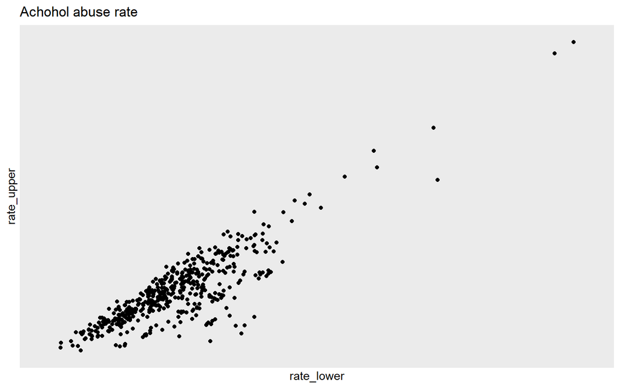

```r
#visualize the abuse rate

alcohol_rate_plot<- ggplot(alcohol_df, aes(x=rate_lower, y=rate_upper)) +
  scale_x_discrete(guide = guide_axis(check.overlap = TRUE))+
  scale_y_discrete(guide = guide_axis(check.overlap = TRUE))+
  geom_point() +labs(title="Achohol abuse rate")

alcohol_rate_plot
```

Drug dataset: lower abuse rate vs upper abuse rate

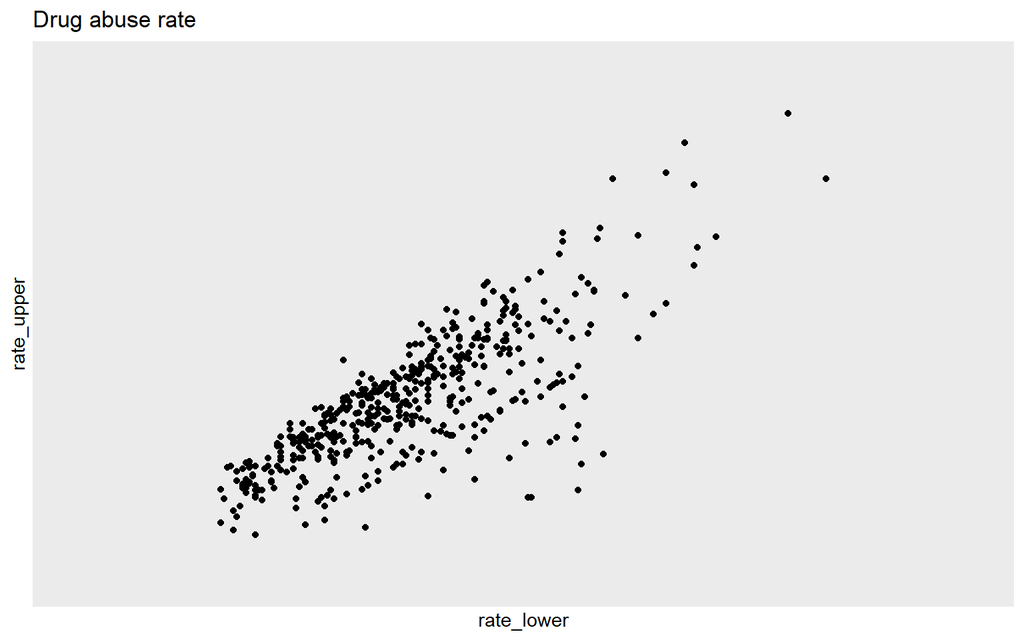

```r
drug_rate_plot<- ggplot(drug_df, aes(x=rate_lower, y=rate_upper)) +
  scale_x_discrete(guide = guide_axis(check.overlap = TRUE))+
  scale_y_discrete(guide = guide_axis(check.overlap = TRUE))+
  geom_point() +labs(title="Drug abuse rate")

drug_rate_plot
```

## Remove outliers

By sorting the values in descending order and remove the top a few points

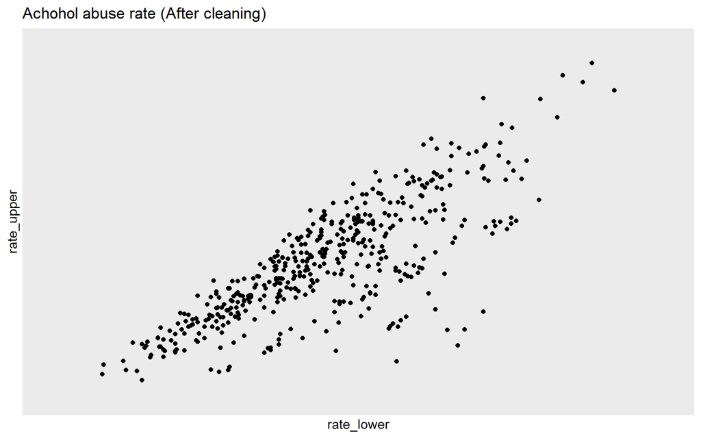

```r
#Remove outliers

sort_alcohol<-alcohol_df[order(alcohol_df$rate_lower,alcohol_df$rate_upper,decreasing = TRUE),]
sort_alcohol<- sort_alcohol[-c(1:7),]

nonoulier_alcohol<-ggplot(sort_alcohol, aes(x=rate_lower, y=rate_upper)) +
  scale_x_discrete(guide = guide_axis(check.overlap = TRUE))+
  scale_y_discrete(guide = guide_axis(check.overlap = TRUE))+
  geom_point() +labs(title="Achohol abuse rate (After cleaning)")

nonoulier_alcohol
```

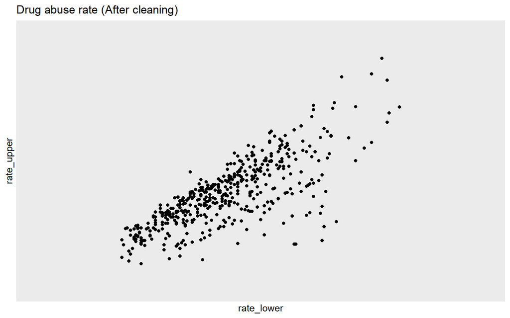

```r
#Remove outliers

sort_drug<-drug_df[order(drug_df$rate_lower,drug_df$rate_upper,decreasing = TRUE),]
sort_drug<- sort_drug[-c(1:2),]

nonoulier_drug<-ggplot(sort_drug, aes(x=rate_lower, y=rate_upper)) +
  scale_x_discrete(guide = guide_axis(check.overlap = TRUE))+
  scale_y_discrete(guide = guide_axis(check.overlap = TRUE))+
  geom_point() +labs(title="Drug abuse rate (After cleaning)")

nonoulier_drug
```

## Save the cleaned datasets

```r
write.csv(sort_alcohol,'alcohol_abouse_r.csv')

write.csv(sort_drug,'Drug_abouse_r.csv')
```

## Combine two datasets and label them

```r
#combine the two datasets and label them
alcohol_df$type<-"Alcohol"
drug_df$type<-"Drug"

alcohol_drug_df<-rbind(alcohol_df,drug_df)
```

```r
write.csv(alcohol_drug_df,'alcohol_drug_df.csv')
```